# Overview of bigPLScox

Frédéric Bertrand

Cedric, Cnam, Paris  
frederic.bertrand@lecnam.net

2025-11-06

# Introduction

The goal of **bigPLScox** is to provide Partial Least Squares (PLS) variants of the Cox proportional hazards model that scale to high-dimensional survival settings. The package implements several algorithms tailored for large-scale problems, including sparse, grouped, and deviance-residual-based approaches. It integrates with the **bigmemory** ecosystem so that data stored on disk can be analysed without exhausting RAM.

This vignette gives a quick tour of the core workflows. It highlights how to prepare data, fit a model, assess model quality, and explore advanced extensions. The complementary vignette “Getting started with bigPLScox” offers a more hands-on tutorial, while “Benchmarking bigPLScox” focuses on performance comparisons.

# Package highlights

- **Generalised PLS Cox regression** via `coxgpls()` with support for grouped predictors.
- **Sparse and structured-sparse extensions** through `coxsgpls()` and `coxspls_sgpls()`.
- **Deviance-residual estimators** such as `coxgplsDR()` for increased robustness.
- **Cross-validation helpers** (`cv.coxgpls()`, `cv.coxsgpls()`, …) to select the number of latent components.
- **Big-memory interfaces** (`big_pls_cox()`, `big_pls_cox_gd()`) designed for file-backed matrices stored with **bigmemory**.

# Available algorithms

The following modeling functions are provided:

- `coxgpls()` for generalized PLS Cox regression.
- `coxsgpls()` and `coxspls_sgpls()` for sparse and structured sparse extensions.
- `coxgplsDR()` and `coxsgplsDR()` for deviance-residual-based estimation.
- `cv.coxgpls()` and related `cv.*` helpers for component selection.

For stochastic gradient descent on large data the package includes `big_pls_cox()` and `big_pls_cox_gd()`.

# Loading an example dataset

The package ships with a small allelotyping dataset that we use throughout this vignette. The data include censoring indicators alongside a large set of predictors.

```r
library(bigPLScox)

data(micro.censure)
data(Xmicro.censure_compl_imp)

train_idx <- seq_len(80)
Y_train <- micro.censure$survyear[train_idx]
C_train <- micro.censure$DC[train_idx]
X_train <- Xmicro.censure_compl_imp[train_idx, -40]
```

# Fitting a PLS-Cox model

`coxgpls()` provides a matrix interface that mirrors `survival::coxph()` but adds latent components to stabilise estimation in high dimensions.

```r
fit <- coxgpls(
  X_train,
  Y_train,
  C_train,
  ncomp = 6,
  ind.block.x = c(3, 10, 15)
)
fit
```

```
#> Call:
#> coxph(formula = YCsurv ~ ., data = tt_gpls)
#>
#>          coef exp(coef) se(coef)      z       p
#> dim.1 -0.6003    0.5486   0.2197 -2.733 0.00628
#> dim.2 -0.6876    0.5028   0.2816 -2.442 0.01460
#> dim.3 -0.4922    0.6113   0.2498 -1.971 0.04877
#> dim.4  0.2393    1.2703   0.2861  0.836 0.40292
#> dim.5 -0.3689    0.6915   0.2200 -1.677 0.09359
#> dim.6  0.1570    1.1700   0.2763  0.568 0.56979
#>
#> Likelihood ratio test=23.99  on 6 df, p=0.0005249
#> n= 80, number of events= 17
```

# Model assessment

Cross-validation helps decide how many components should be retained. The `cv.coxgpls()` helper accepts either a matrix or a list containing `x`, `time`, and `status` elements.

```r
set.seed(123)
cv_res <- cv.coxgpls(
  list(x = X_train, time = Y_train, status = C_train),
  nt = 10,
  ind.block.x = c(3, 10, 15)
)
```

```
#> CV Fold 1
#> CV Fold 2
#> CV Fold 3
#> CV Fold 4
#> CV Fold 5
```

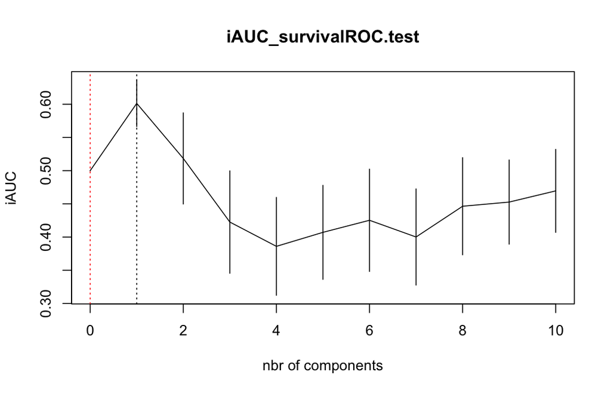

```r
cv_res
```

```
#> $nt
#> [1] 10
#>
#> $cv.error10
#>  [1] 0.5000000 0.6013049 0.5183694 0.4226056 0.3860331 0.4071207 0.4252845
#>  [8] 0.4001223 0.4464093 0.4526887 0.4695600
#>
#> $cv.se10
#>  [1] 0.00000000 0.03487588 0.06866706 0.07717020 0.07373734 0.07084802
#>  [7] 0.07707939 0.07247893 0.07317843 0.06341118 0.06252387
#>
#> $folds
#> $folds$`1`
#>  [1] 31 42 69 75 72 12 66 27 71 55 58 49 11 30 37 22
#>
#> $folds$`2`
#>  [1] 79 50 57 68 17 15 64 74 34 13 80 76 61  2 24 35
#>
#> $folds$`3`
#>  [1] 51 43  9 62 73 32 41 78 29 18  6 16 44 59 33 48
#>
#> $folds$`4`
#>  [1] 14 77 26 19 39 65 10 56  5  1 21 20 46 60  3 47
#>
#> $folds$`5`
#>  [1] 67 25  7 36 53 45 23 38  8 40 54 28 52  4 70 63
#>
#>
#> $lambda.min10
#> [1] 1
#>
#> $lambda.1se10
#> [1] 0
```

# Alternative estimators

Deviance-residual-based estimators provide increased robustness by iteratively updating residuals. Sparse variants enable feature selection in extremely high-dimensional designs.

```r
dr_fit <- coxgplsDR(
  X_train,
  Y_train,
  C_train,
  ncomp = 6,
  ind.block.x = c(3, 10, 15)
)
dr_fit
```

```
#> Call:
#> coxph(formula = YCsurv ~ ., data = tt_gplsDR)
#>
#>          coef exp(coef) se(coef)     z        p
#> dim.1 0.92699   2.52690  0.23301 3.978 6.94e-05
#> dim.2 0.85445   2.35008  0.27352 3.124  0.00178
#> dim.3 0.56308   1.75607  0.29847 1.887  0.05922
#> dim.4 0.49242   1.63627  0.32344 1.522  0.12789
#> dim.5 0.18706   1.20569  0.38769 0.482  0.62946
#> dim.6 0.08581   1.08960  0.31517 0.272  0.78541
#>
#> Likelihood ratio test=51.46  on 6 df, p=2.39e-09
#> n= 80, number of events= 17
```

Additional sparse estimators can be invoked via `coxsgpls()` and `coxspls_sgpls()` by providing `keepX` or `penalty` arguments that control the number of active predictors per component.

# Working with big data

For extremely large problems, stochastic gradient descent routines operate on memory-mapped matrices created with **bigmemory**. The helper below converts a standard matrix to a `big.matrix` and runs a small example.

```r
X_big <- bigmemory::as.big.matrix(X_train)
big_fit <- big_pls_cox(
  X_big,
  time = Y_train,
  status = C_train,
  ncomp = 6
)
big_fit
```

[output not shown]

[output cut: 357 more lines]

The `big_pls_cox_gd()` function exposes a gradient-descent variant that is often preferred for streaming workloads. Both functions can be combined with `foreach::foreach()` for multi-core execution.

# Further reading

- `vignette("getting-started", package = "bigPLScox")` for a detailed walkthrough of data preparation and model diagnostics.
- `vignette("bigPLScox-benchmarking", package = "bigPLScox")` for reproducible performance comparisons.
- The package website at https://fbertran.github.io/bigPLScox/ hosts reference documentation and additional examples.